# Computer Science project.

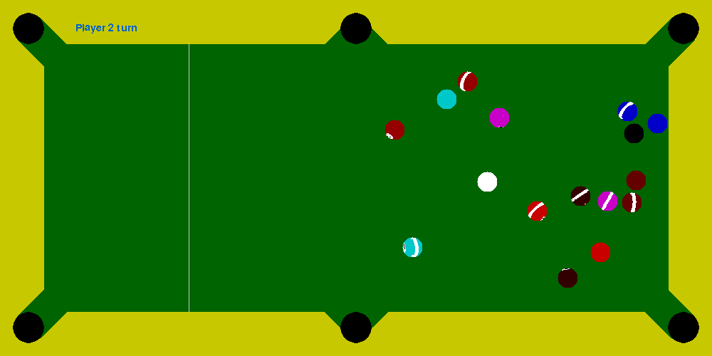

Potting the teal ball 2/4

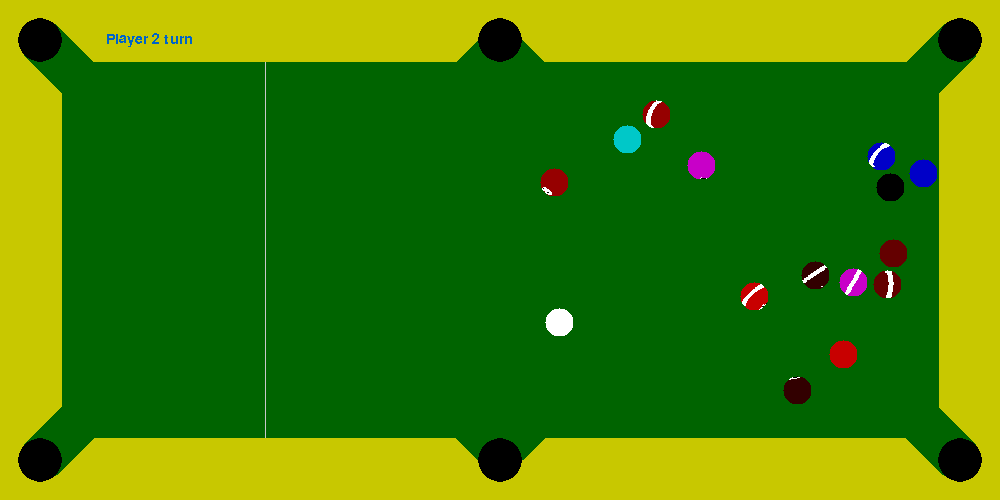

Potting the teal ball 3/4

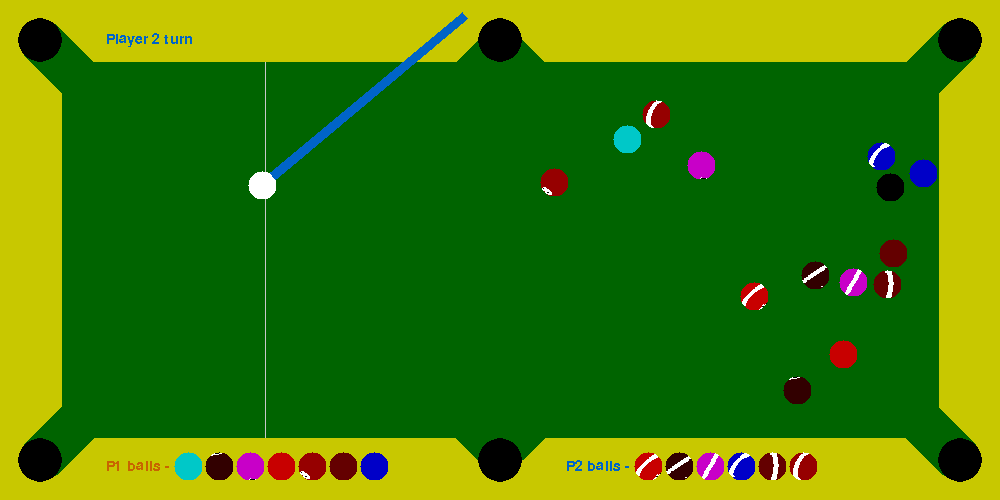

Potting the teal ball 4/4

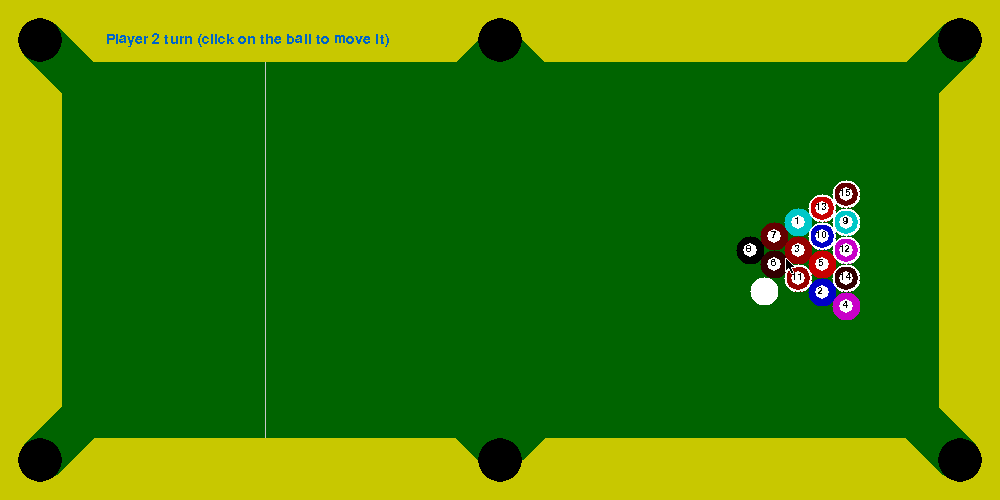

Attempting to put the ball into the another ball

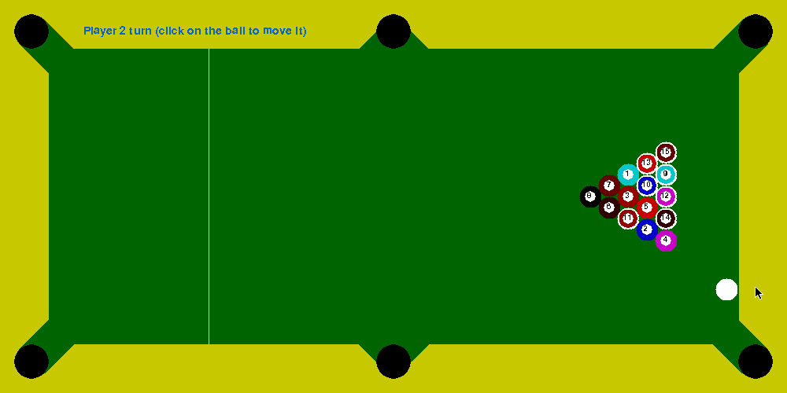

Attempting to put the ball into the wall

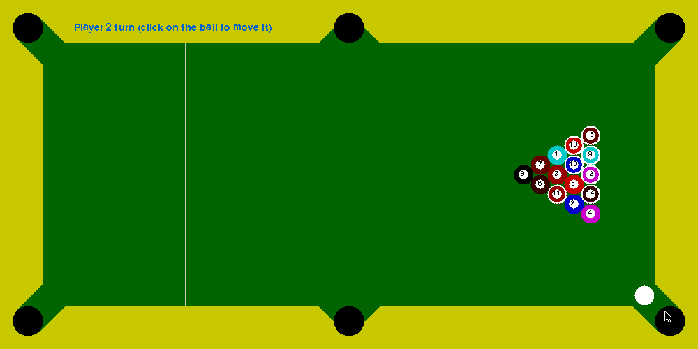

Attempting to put the ball into the pocket

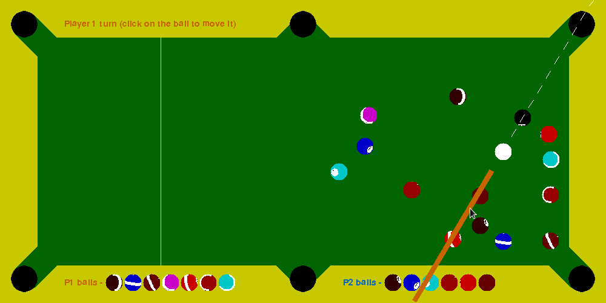

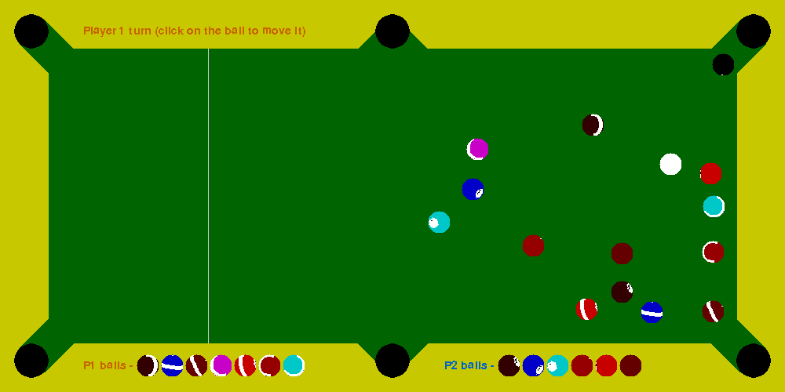

Potting the 8ball illegally 2/3

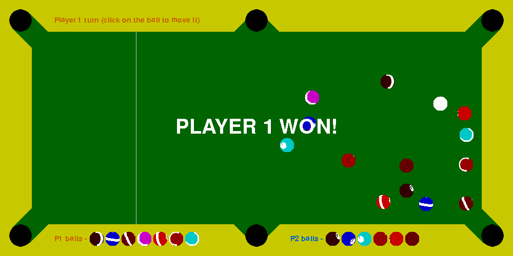

Potting the 8ball illegally 3/3

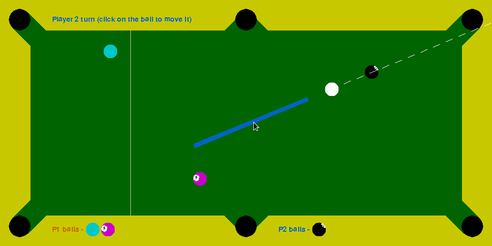

Potting the 8ball legally 1/3

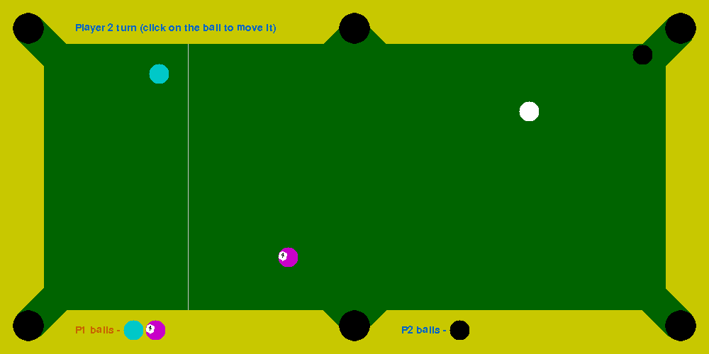

Potting the 8ball legally 2/3

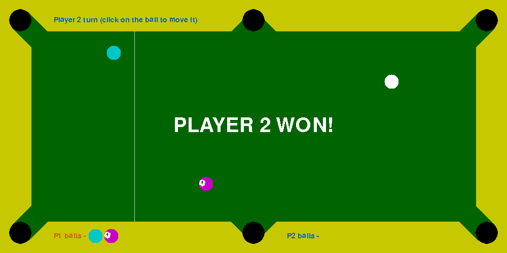

Potting the 8ball legally 3/3

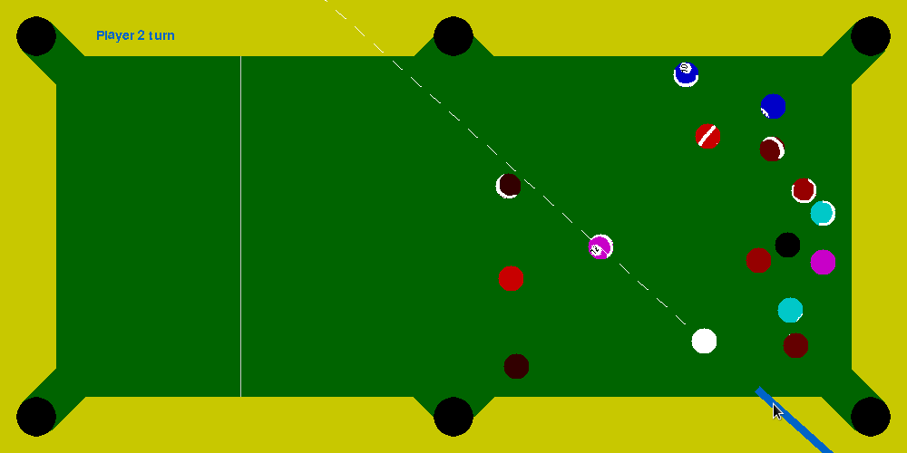

Potting a ball before the groups have been assigned 1/4

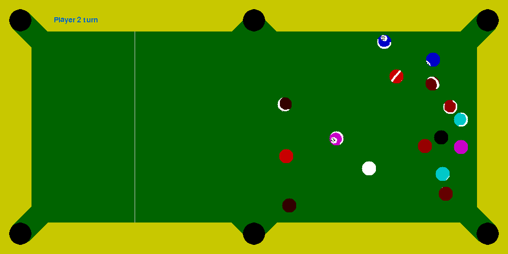

Potting a ball before the groups have been assigned 2/4

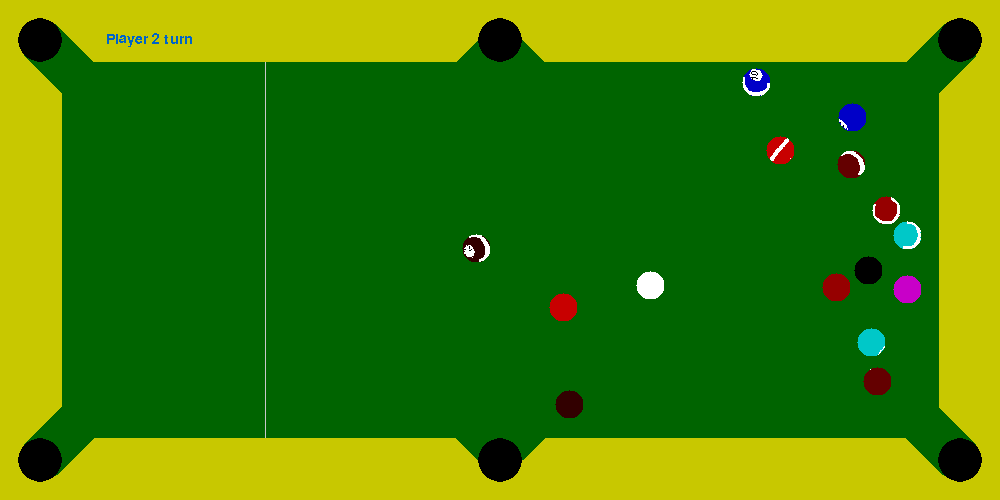

Potting a ball before the groups have been assigned 3/4

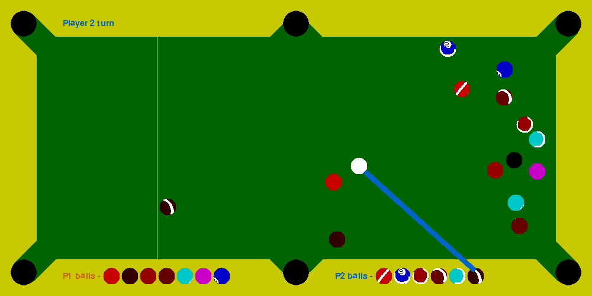

Potting a ball before the groups have been assigned 4/4

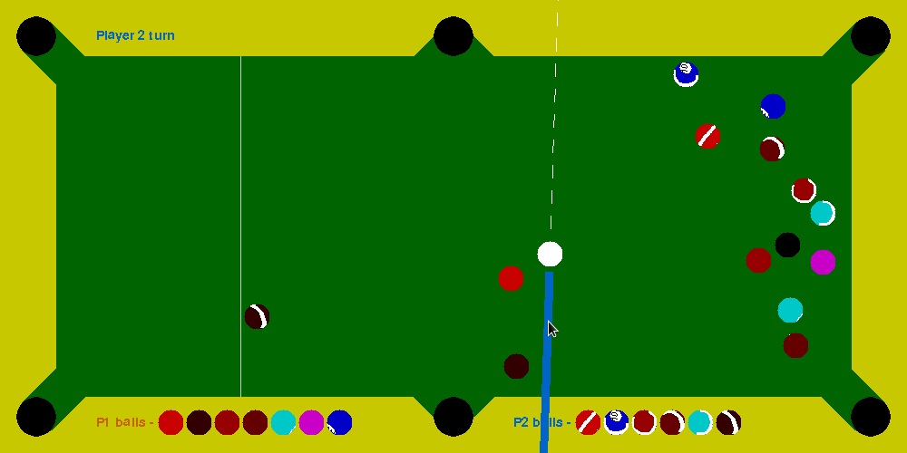

Not hitting a single ball in a turn 1/3

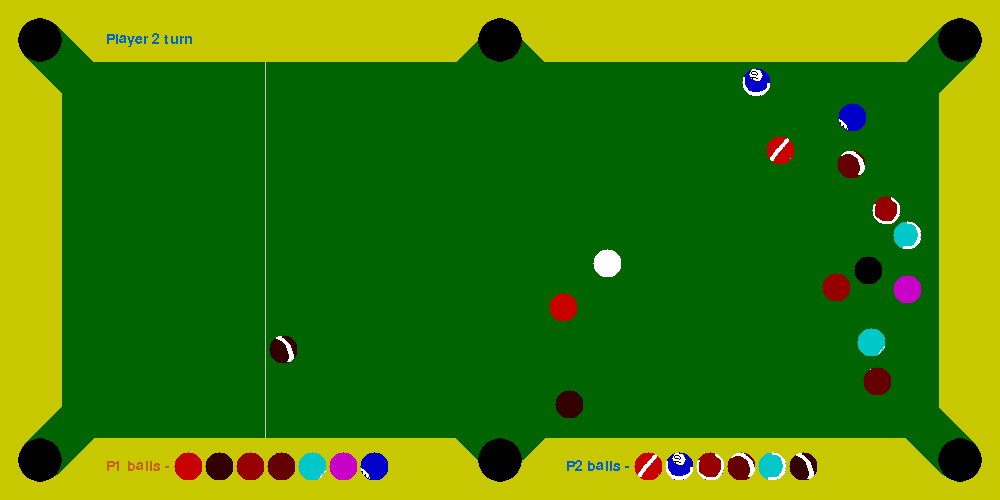

Not hitting a single ball in a turn 2/3

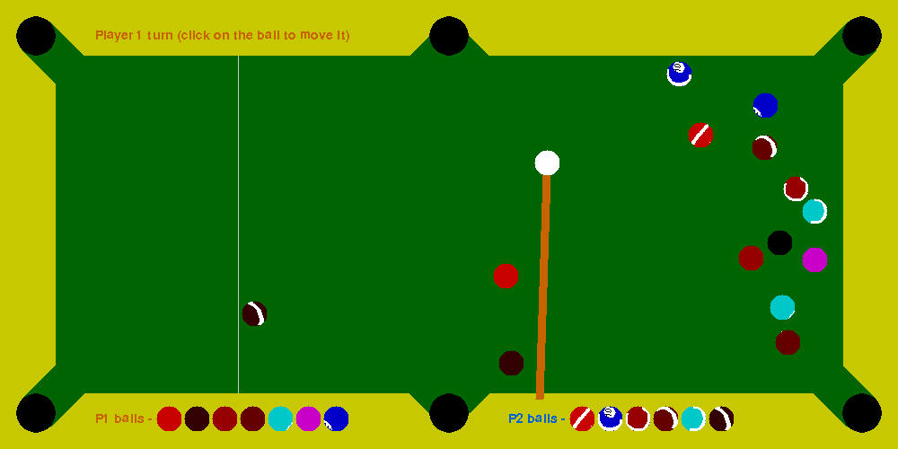

Not hitting a single ball in a turn 3/3

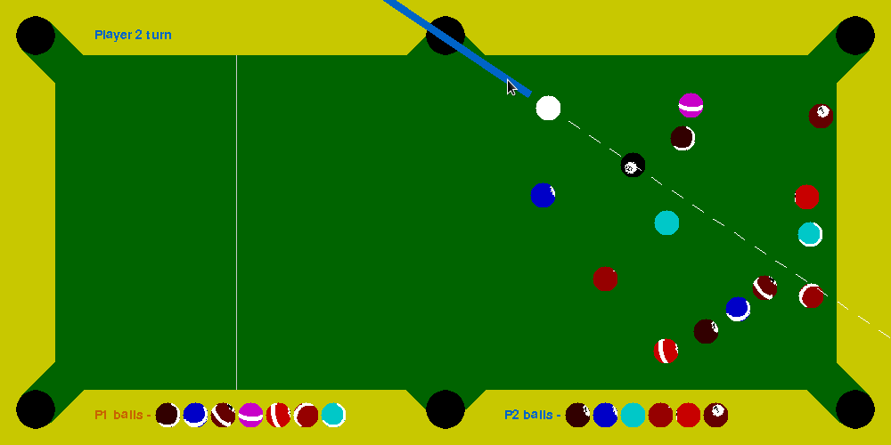

Hitting the 8ball 1/4

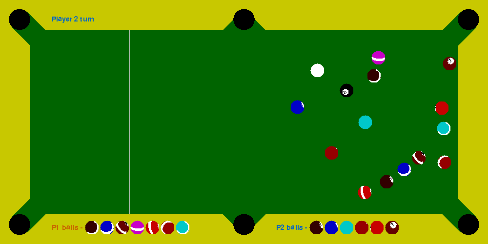

Hitting the 8ball 2/4

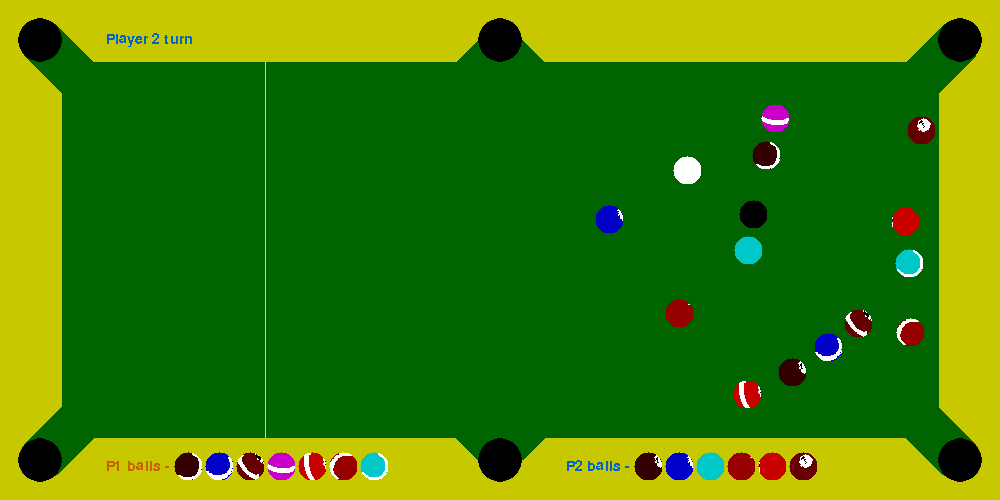

Hitting the 8ball 3/4

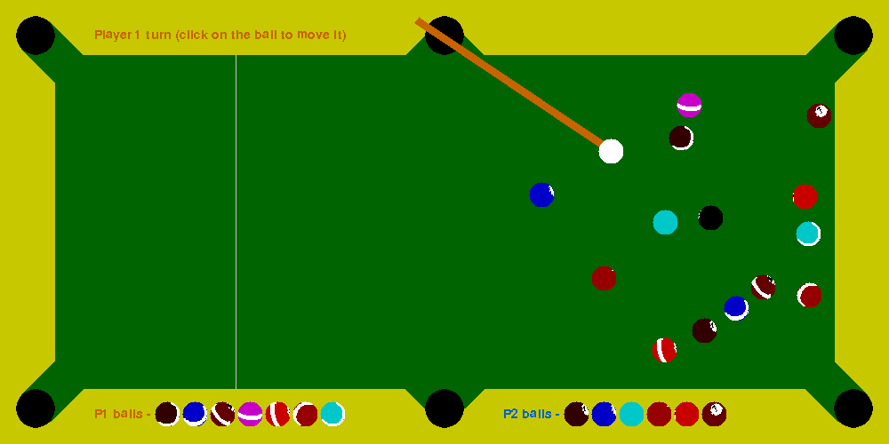

Hitting the 8ball 4/4

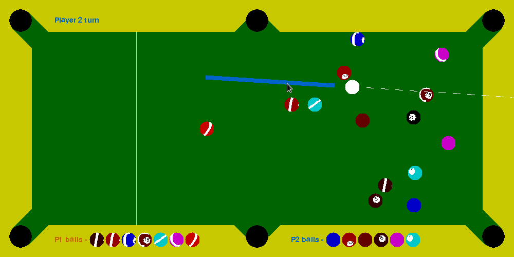

Hitting a ball from the opposite group 1/4

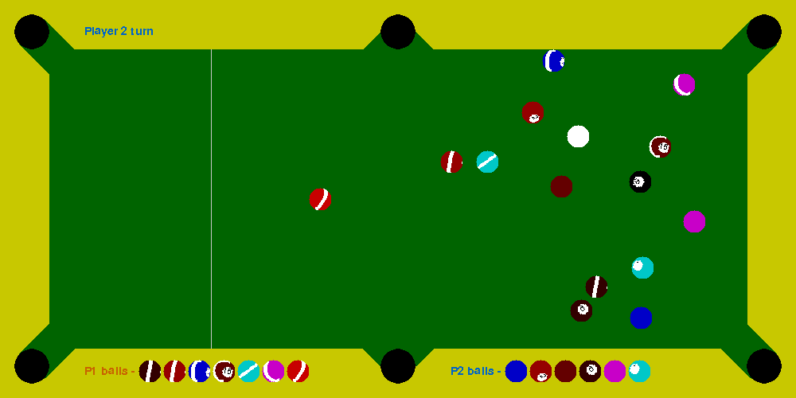

Hitting a ball from the opposite group 2/4

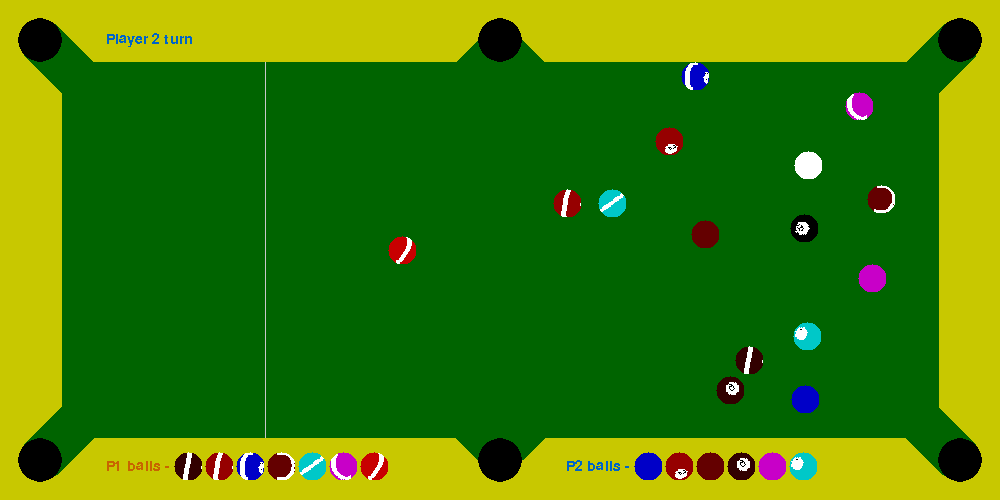

Hitting a ball from the opposite group 3/4

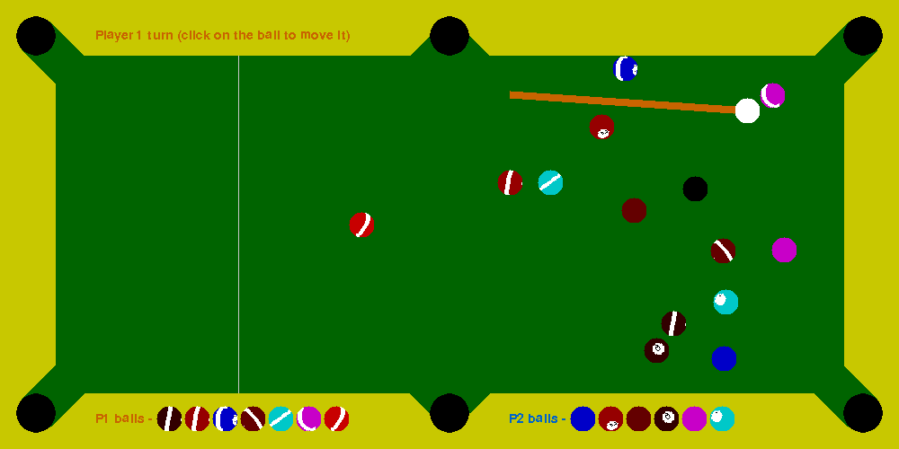

Hitting a ball from the opposite group 4/4

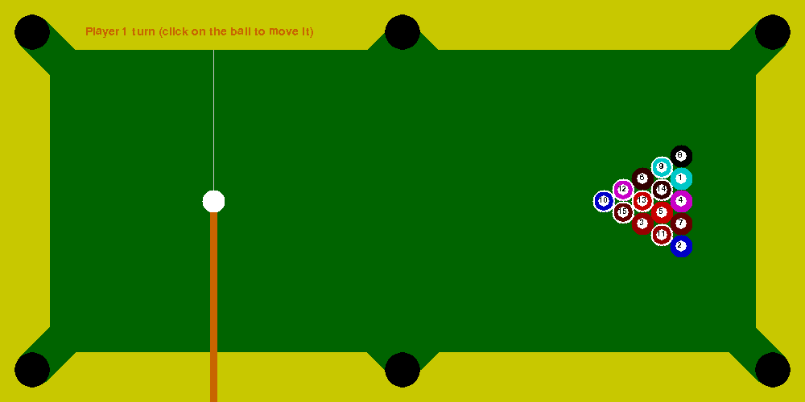

Initial state of the first screen of the game

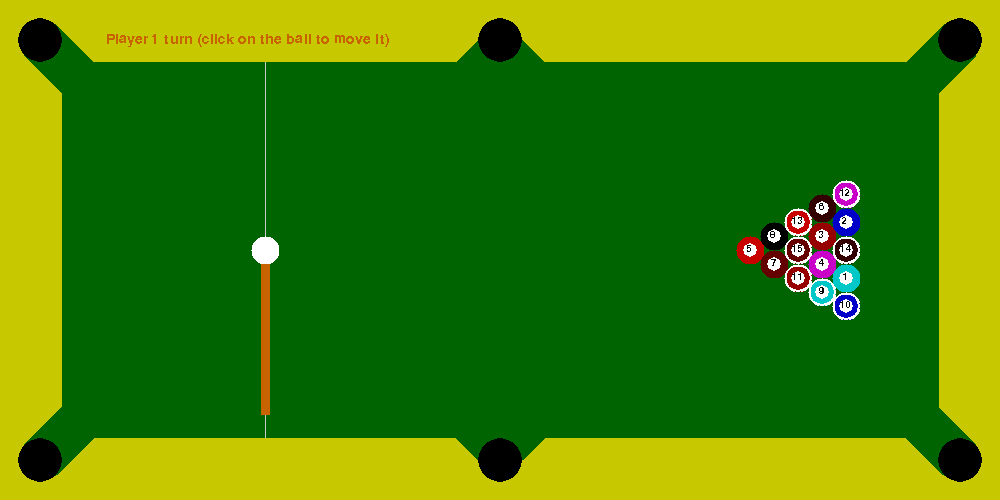

Decreased cue_length variable in the configuration file

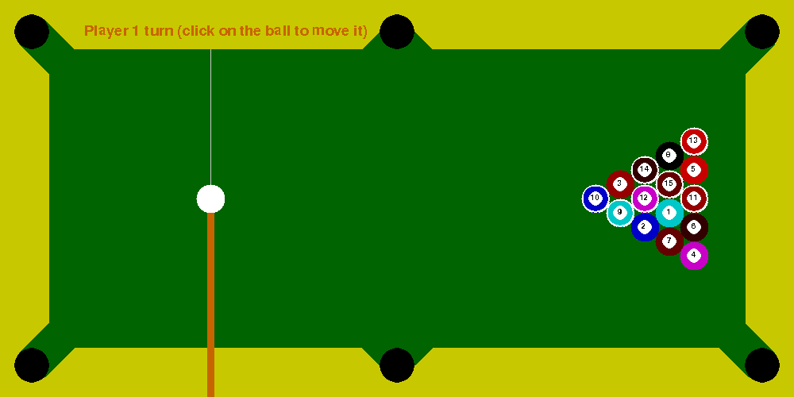

Increased ball_radius variable in the configuration file

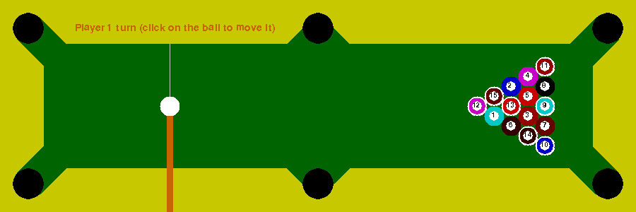

Changed resolution variable in the configuration file

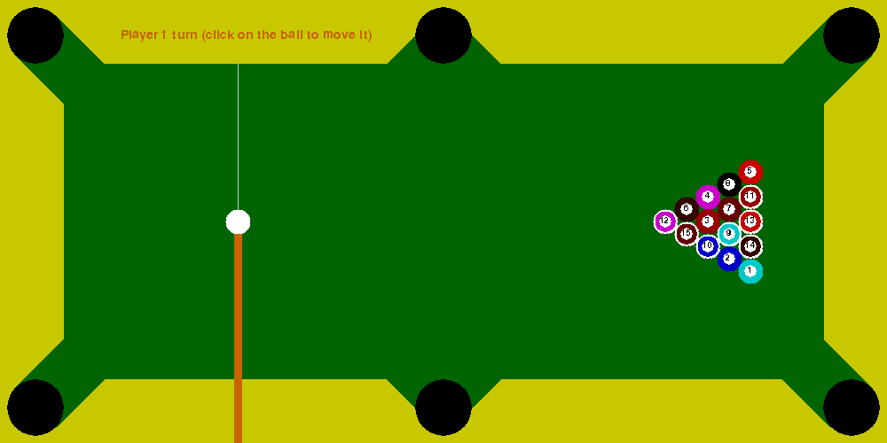

Increased hole_radius variable in the configuration file

# Evaluation

## Objective Analysis

Here are the objectives set for this project:

- The rules of pool should be implemented in the game
- The game should run at more than 30 frames per second
- Physical interactions in the game should be realistic:
  - The movement of the balls should be affected by friction
  - The ball collisions should be inelastic
  - The game should detect and resolve ball-ball and ball-table side collisions correctly
- Game animations should look realistic:
  - The balls should visibly rotate when moving
  - The cue should move towards the ball when a player is hitting a ball
- There should be a configuration file, which can change some of the in-game options like ball size or cue hit power
- An installation guide/README file for users should be present

Collisions, ball movement and game rules were completed and tested in Testing section[5][6].

The hardest part of the animations in the game was the ball. The stripes on the ball are rendered approximately, meaning the algorithm does not use a large amount of polygons to model the stripe, but because the balls are small in game, this is hardly noticeable[5]. This condition was met.

The game frame per second limit was set to 60 fps, and judging from looks, it runs at steady 60 frames per second without visible tearing. The frame per second limit variable can be changed in the configuration file[5]. This condition was met.

Talking about the configuration file, the configuration options are perhaps too extensive and contain stuff you wouldn’t expect, for example, you could change the position of the individual pockets in the file. Even though the file is written in python, users won’t need to know python to change these settings, because the file looks like a normal text file. This mostly because of pythons high level syntax which is very close to pseudocode[6]. The configuration condition was met.

The installation guide for Linux and Windows users is included in the README file. Because python has to install the required modules before the game could be played, the installation for windows users requires the command line. For Linux, however, there is a simple shell script which creates a virtual environment, installs the required modules, and starts the game.This condition was met.

Therefore, all objectives were met.

## User Feedback

I have interviewed my classmate again after he installed and played the game on his machine.

**Was the game easy to install?**

*Installing the game using the included shell script was as easy as it gets. Just download the repository and run the starting script.*

**How was your gameplay experience?**

*The game is simple and has appealing graphics. The collisions and the rules work well. I’ve had a lot of fun changing the values in the configuration file too see how the game would behave.*

**Did you encounter any bugs or errors?**

*Not in the normal play mode, no. After changing some of the values in the configuration file the game became unplayable, for example, I made the balls bigger than the pockets and removed movement friction once, and the game did not handle that very well, however I was breaking it intentionally and it’s more entertaining if the game allows you to break it. The game ran very smoothly, too.*

As expected, the user is satisfied with the solution. One thing to consider, is the fact that the user was using a Linux operating system, which made the process of installing the game easier. The installation process might be more inconvenient on other operating systems.

Besides the interview, the game became surprisingly popular online, gaining traffic on GitHub (see Figure 58) and, at the time of writing this, becoming the first search result on Google for “python pool game”, which is, admittedly, a very specific search query.

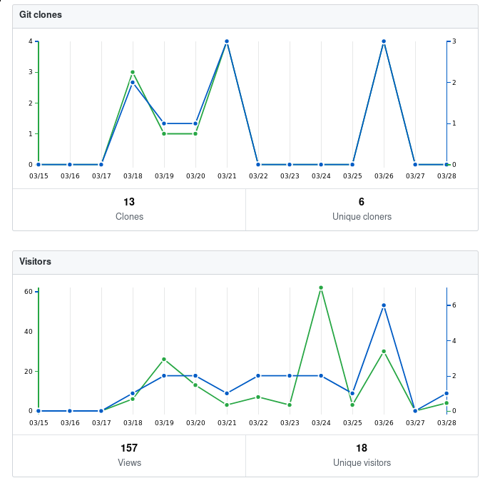

Github repository traffic report

## Possible Extensions

Multiplayer for this game is something I would like to implement, but it would to complex for me alone, because it would require good network development knowledge, which I do not have. Additionally, it requires a server to overlook the players’ actions and to synchronise both programs and I don’t have a dedicated server, too.

One similar feature I would like to implement, but lack the resources to do so, is an AI player. While it is significantly easier to implement AI than multiplayer, after looking into this problem I have not found an easy way to do this. One algorithm for AI which caught my attention was:

1. Find every possible ball on the table you can hit.
2. Check which balls have a direct unblocked path to a pocket.
3. Calculate where the point of contact must be made to hit the ball into that pocket.
4. Calculate the angle of the cue required so that the cue ball would hit the target ball at the correct point of contact.

This is a fairly simple algorithm but there are several problems with it. Firstly, it’s not trivial to find the list of balls you can hit, without hitting another ball. One way to do that is - whenever you are checking a particular ball, see if any other balls between the cue ball and the target ball. In terms of speed, that is would be $\mathcal{O}(n^2)$, because the algorithm would have to iterate through every ball for every ball. Same for checking if the ball has an unblocked path to the pocket. Another way to implement this would be machine learning algorithms, but these are famous for requiring high level mathematics knowledge which I lack.

Another design choice which could be improved is the stripe rendering algorithm. The problem with the algorithm is that it is an approximation and can be wrong when looked into very carefully.

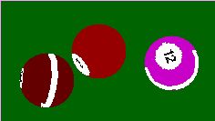

A picture of balls in-game

Finally, as seen in the User Feedback section of this chapter, the user had no problems installing the game, however that is mostly because the user was using a Linux-based operating system. The installation for Windows users is harder because they have to install the libraries themselves. The installation aspect may be improved by making a special Windows game installer which would allow the game to be installed without (or minimal) user interaction.

# References

[1] Jeroen van Baar Hanspeter Pfister Matthias Zwicker. Surfels: Surface elements as rendering primitives. Retrieved from https://graphics.ethz.ch/research/past_projects/surfels/surfels/index.html

[2] Maksims Kovalovs. Commit 872bdde305882ee68b771a3a03be3ab264d586ca - fixed a "reverse shot" bug. Removed graphics optimisation. Retrieved from https://github.com/max-kov/pool/commit/872bdde305882ee68b771a3a03be3ab264d586ca#diff-907fb60709078447681c52022334d974R113

[3] Maksims Kovalovs. Commit 5b35af32b22ac06268ee5231a2aa6834f599d59c - migrated to numpy. Retrieved from https://github.com/max-kov/pool/commit/5b35af32b22ac06268ee5231a2aa6834f599d59c#diff-1919d6b68248eec2b8d15bbc72b8e357R31

[4] Maksims Kovalovs. Pool game on github. Retrieved from https://github.com/max-kov/pool

[5] Maksims Kovalovs. Pool gameplay testing video number 1. Retrieved from https://www.youtube.com/watch?v=rg0-kHyMUhQ

[6] Maksims Kovalovs. Pool gameplay testing video number 2. Retrieved from https://www.youtube.com/watch?v=rg0-kHyMUhQ

[7] raysmith619. Two dimensional pool game in python. Retrieved from https://github.com/raysmith619/PoolGame

[8] thinkpixellab. An html5 pool game...with bombs! Retrieved from https://github.com/CIS580F17/pool

[9] vlab.amrita.edu. Elastic and inelastic collision. Retrieved from http://vlab.amrita.edu/?sub=1&brch=68&sim=189&cnt=1

[10] WolframMathWorld. Rotation matrix. Retrieved from http://mathworld.wolfram.com/RotationMatrix.html

[11] User installation issue. Retrieved from https://github.com/thinkpixellab/agent8ball/issues/31

[12] Agent8ball commit history. Retrieved from https://github.com/thinkpixellab/agent8ball/commits/master

[13] Tyre modelling for rolling resistance. Retrieved from publications.lib.chalmers.se/records/fulltext/200040/200040.pdf

[14] Numpy library main website. Retrieved from http://www.numpy.org/

[15] TIOBE index website. Retrieved from https://www.tiobe.com/tiobe-index/

[16] PYPL popularity of programming language. Retrieved from http://pypl.github.io/PYPL.html

[17] Game engine. Retrieved from http://wiki.freepascal.org/Game_Engine

[18] The podcast about the delphi programming language, tools, news and community. Retrieved from http://delphi.org/2011/10/pascal-game-development

[19] Pygame github page. Retrieved from https://github.com/pygame/pygame

[20] Pool rules. Retrieved from http://www.epa.org.uk/wrules.php

[21] Retrieved from graphics.stanford.edu/courses/cs348a-17-winter/ReaderNotes/handout12.pdf

[22] Retrieved from graphics.stanford.edu/courses/cs348a-17-winter/ReaderNotes/handout17.pdf

[23] Version control systems popularity in 2016. Retrieved from https://rhodecode.com/insights/version-control-systems-2016

[^1]: https://github.com/max-kov/pool/commits/master
[^2]: https://travis-ci.org/max-kov/pool/builds